# Myers Briggs personality prediction

Myers-Briggs Type Indicator (MBTI) is a personality test, typically based on psychological attributes and is used to determine differing strengths and types of personalities in a workplace or other setting. The questionnaire’s battery of tests can provide insight into the subject’s perception, decision making, leadership skills, and other attributes may contribute to personal or professional success.

The MBTI then segments subjects into 16 distinct personality types, using combinations of the following personality designations.

Introvert (I) vs. Extrovert (E) Introverts tend to consider the world from an internal perspective, allowing their ideas and creativity to flow from within themselves. Introverts tends to attach more emotional value to their thoughts and decisions.

Extroverts gain their inspiration through interactions and ideation with others. This external view tends to make extroverts more collaborative.

Intuitive (N) vs. Sensory (S) Intuitive types focus more on the future by recognizing patterns and processes in order to have a greater understanding of potential results.

Sensory types tend to live more in the moment and rely on holistic views through their use of immediate senses.

Thinking (T) vs. Feeling (F) Thinking types take an objective approach to situations, and rely more on causal analysis and data to help form their opinions or decisions.

Feeling types place considerable weight to external values as part of their decision making, giving more emphasis to the subjective aspects of a situation, and considering personal differences.

Perceiving (P) vs. Judging (J) Perceiving types go with the flow, and enjoy flexibility and spontaneity when it comes to agendas or decisions.

Judging types take an organized approach to life, and prefer that events be planned out or scheduled in order to go as smoothly as possible

There are 16 different personality types:

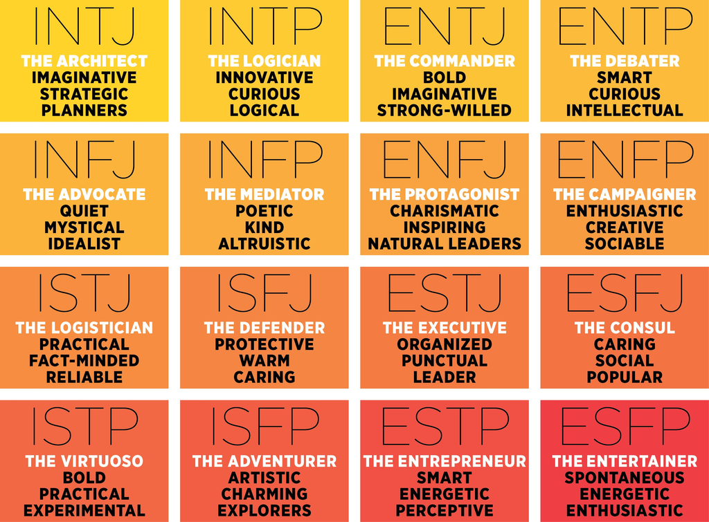

# Project Idea

The Myers Briggs Type Indicator is a personality type system that divides a person into 16 distinct personalities based on introversion, intuition, thinking and perceiving capabilities. We can identify the personality of a person from the type of posts they put on social media.

I have downloaded the dataset from : https://www.kaggle.com/datasnaek/mbti-type. This dataset contains over 8600 rows. Each row has

- Type
- posts separated by '|||'

I have used NLP(Natural Language processing ) for this project .

Lets start out project by first cleaning the data .

# Data cleaning

First step is to import the libraries

```python
import numpy as np
import pandas as pd
import os
import seaborn as sns
import matplotlib.pyplot as plt
```

Let's now read the downloaded dataset.

```python
dataset=pd.read_csv('mbti_1.csv')
```

The first 20 elements of the dataset can be viewed using following method. Columns are type and posts.

```python
dataset.head(20)
```

|  | type | posts |
| --- | --- | --- |
| 0 | INFJ | 'http://www.youtube.com/watch?v=qsXHcwe3krw\|\|\|... |
| 1 | ENTP | 'I'm finding the lack of me in these posts ver... |
| 2 | INTP | 'Good one _____ https://www.youtube.com/wat... |
| 3 | INTJ | 'Dear INTP, I enjoyed our conversation the o... |
| 4 | ENTJ | 'You're fired.\|\|\|That's another silly misconce... |
| 5 | INTJ | '18/37 @.@\|\|\|Science is not perfect. No scien... |
| 6 | INFJ | 'No, I can't draw on my own nails (haha). Thos... |
| 7 | INTJ | 'I tend to build up a collection of things on ... |
| 8 | INFJ | I'm not sure, that's a good question. The dist... |
| 9 | INTP | 'https://www.youtube.com/watch?v=w8-egj0y8Qs\|\|... |
| 10 | INFJ | 'One time my parents were fighting over my dad... |
| 11 | ENFJ | 'https://www.youtube.com/watch?v=PLAaiKvHvZs\|\|... |
| 12 | INFJ | 'Joe santagato - ENTP\|\|\|ENFJ or ENTP? I'm n... |
| 13 | INTJ | 'Fair enough, if that's how you want to look a... |
| 14 | INTP | 'Basically this... https://youtu.be/1pH5c1Jkh... |
| 15 | INTP | 'Your comment screams INTJ, bro. Especially th... |
| 16 | INFJ | 'some of these both excite and calm me: BUTTS... |
| 17 | INFP | 'I think we do agree. I personally don't consi... |
| 18 | INFJ | 'I fully believe in the power of being a prote... |
| 19 | INFP | 'That's normal, it happens also to me. If I am... |

The concise summary of our dataframe is :

```python
dataset.info()
```

```
<class 'pandas.core.frame.DataFrame'>
RangeIndex: 8675 entries, 0 to 8674
Data columns (total 2 columns):
 #   Column  Non-Null Count  Dtype
---  ------  --------------  -----
 0   type    8675 non-null   object
 1   posts   8675 non-null   object
dtypes: object(2)
memory usage: 135.7+ KB
```

```python
dataset.describe()
```

|  | type | posts |
| --- | --- | --- |
| count | 8675 | 8675 |
| unique | 16 | 8675 |
| top | INFP | 'INTP?? I don't know, I think he's hard to typ... |
| freq | 1832 | 1 |

Split the dataset into training and holdout sets using module train_test_split.

```python
from sklearn.model_selection import train_test_split
```

```python
personality, rem = train_test_split( dataset, random_state=42, test_size=0.01, stratify=dataset["type"])
```

Save the splitted training and holdout datasets.

```python
personality.to_csv("personal.csv",index=False)
```

```python
rem.to_csv("rem.csv",index=False)
```

Check the value counts of the two dataframes to ensure that the data is stratified

```python
print(personality["type"].value_counts())
```

```
INFP    1814
INFJ    1455
INTP    1291
INTJ    1080
ENTP     678
ENFP     668
ISTP     334
ISFP     268
ENTJ     229
ISTJ     203
ENFJ     188
ISFJ     164
ESTP      88
ESFP      47
ESFJ      42
ESTJ      39
Name: type, dtype: int64
```

```python
print(rem["type"].value_counts())
```

```
INFP    18
INFJ    15
INTP    13
INTJ    11
ENTP     7
ENFP     7
ISTP     3
ISFP     3
ISTJ     2
ENTJ     2
ENFJ     2
ISFJ     2
ESFP     1
ESTP     1
Name: type, dtype: int64
```

Read the personal dataset that will be used further for traning and testing.

```python
personality_test=pd.read_csv("personal.csv")
```

View the first five rows of our new dataframe

```python
personality_test.head()
```

|  | type | posts |
| --- | --- | --- |
| 0 | INFJ | 'When asked of the things you wish you did ear... |
| 1 | INFJ | 'I love both and they are equally important to... |
| 2 | INFJ | Really? You think implying that everyone who i... |
| 3 | ENFJ | 'Love is a crazy thing. Se is our best form ... |
| 4 | INTP | 'I am a physics undergrad with a computation e... |

Check the number of rows and columns in personality_test dataframe

```python
personality_test.shape
```

```
(8588, 2)
```

The sixteen classes of myers briggs personality is imbalanced as visually shown below.

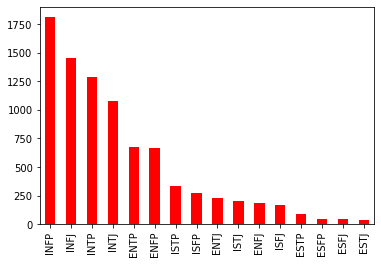

```python
personality_test["type"].value_counts().plot(kind="bar",color="red")
plt.show()
```

```python
personality_test["Extrovert"] = personality_test["type"].apply(lambda x: 1 if x[0] == "E" else 0)
personality_test["Sensing"] = personality_test["type"].apply(lambda x: 1 if x[1] == "S" else 0)
personality_test["Thinking"] = personality_test["type"].apply(lambda x: 1 if x[2] == "T" else 0)
personality_test["Judging"] = personality_test["type"].apply(lambda x: 1 if x[3] == "J" else 0)
```

Rearrange data columns.

```python
personality_test = personality_test[["type", "Extrovert", "Sensing", "Thinking", "Judging", "posts"]]
personality_test.head()
```

|  | type | Extrovert | Sensing | Thinking | Judging | posts |
| --- | --- | --- | --- | --- | --- | --- |
| 0 | INFJ | 0 | 0 | 0 | 1 | 'When asked of the things you wish you did ear... |
| 1 | INFJ | 0 | 0 | 0 | 1 | 'I love both and they are equally important to... |
| 2 | INFJ | 0 | 0 | 0 | 1 | Really? You think implying that everyone who i... |
| 3 | ENFJ | 1 | 0 | 0 | 1 | 'Love is a crazy thing. Se is our best form ... |
| 4 | INTP | 0 | 0 | 1 | 0 | 'I am a physics undergrad with a computation e... |

Note: Extroversion vs. Introversion

I - 0 E - 1 Sensing vs. Intuition

N - 0 S - 1 Thinking vs. Feeling

F - 0 T - 1 Judging vs. Perceiving

P - 0 J - 1

Check the individual counts of each balanced classes.

```python
icount = personality_test["Extrovert"].value_counts()[0]
print(f"Introvert Count is : {icount}")
```

```
Introvert Count is : 6609
```

```python
ecount = personality_test["Extrovert"].value_counts()[1]
print(f"Extrovert Count is: {ecount}")
```

```
Extrovert Count is: 1979
```

```python
incount = personality_test["Sensing"].value_counts()[0]
print(f"Intuition Count is: {incount}")
```

```
Intuition Count is: 7403
```

```python
scount = personality_test["Sensing"].value_counts()[1]
print(f"Sensing Count is: {scount}")
```

```
Sensing Count is: 1185
```

```python
fcount = personality_test["Thinking"].value_counts()[0]
print(f"Feeling Count is: {fcount}")
```

```
Feeling Count is: 4646
```

```python
tcount = personality_test["Thinking"].value_counts()[1]
print(f"Thinking Count is: {tcount}")
```

```
Thinking Count is: 3942
```

```python
pcount = personality_test["Judging"].value_counts()[0]
print(f"Perceiving Count is: {pcount}")
```

```
Perceiving Count is: 5188
```

```python
jcount = personality_test["Judging"].value_counts()[1]
print(f"Judging Count is: {jcount}")
```

```
Judging Count is: 3400
```

The class imbalance issue still seem to exist but we will proceed with this for now.

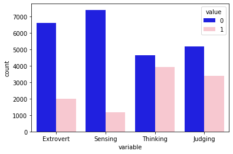

```python
sns.countplot( x="variable",hue="value",data=pd.melt(personality_test[["Extrovert", "Sensing", "Thinking", "Judging"]]),palette=["blue", "pink"],)

plt.show()
```

Import regular expressions to start data cleaning . Actions to be performed are :

- converting posts into lower case
- replacing ||| with space
- dropping links
- dropping emails
- dropping punctuations

```python
import re
```

```python
personality_test["cleaned_posts"] = personality_test["posts"].str.lower()
```

```python
personality_test["cleaned_posts"] = personality_test["cleaned_posts"].str.replace( re.compile(r"\|\|\|"), " ")
```

```python
personality_test["cleaned_posts"] = personality_test["cleaned_posts"].str.replace(re.compile(r"https?:\/\/(www)?.?([A-Za-z_0-9-]+)([\S])*"), "")
```

```python
personality_test["cleaned_posts"] = personality_test["cleaned_posts"].str.replace(re.compile(r"\S+@\S+"), "")
```

```python
personality_test["cleaned_posts"] = personality_test["cleaned_posts"].str.replace(re.compile(r"[^a-z\s]"), " ")
```

Observe the changes made .

```python
personality_test.head(30)
```

|  | type | Extrovert | Sensing | Thinking | Judging | posts | cleaned_posts |
| --- | --- | --- | --- | --- | --- | --- | --- |
| 0 | INFJ | 0 | 0 | 0 | 1 | 'When asked of the things you wish you did ear... | when asked of the things you wish you did ear... |
| 1 | INFJ | 0 | 0 | 0 | 1 | 'I love both and they are equally important to... | i love both and they are equally important to... |
| 2 | INFJ | 0 | 0 | 0 | 1 | Really? You think implying that everyone who i... | really you think implying that everyone who i... |
| 3 | ENFJ | 1 | 0 | 0 | 1 | 'Love is a crazy thing. Se is our best form ... | love is a crazy thing se is our best form ... |
| 4 | INTP | 0 | 0 | 1 | 0 | 'I am a physics undergrad with a computation e... | i am a physics undergrad with a computation e... |
| 5 | INFP | 0 | 0 | 0 | 0 | 'I have done many types of prepared humor, pla... | i have done many types of prepared humor pla... |
| 6 | INTJ | 0 | 0 | 1 | 1 | 'Try reading my post again. You missed a grea... | try reading my post again you missed a grea... |
| 7 | INFP | 0 | 0 | 0 | 0 | 'I actually just don't like being INFP - make ... | i actually just don t like being infp make ... |
| 8 | INFJ | 0 | 0 | 0 | 1 | 'I'm a graphic designer. I currently work part... | i m a graphic designer i currently work part... |
| 9 | INTJ | 0 | 0 | 1 | 1 | 'ENSP: I got a tattoo. Me: Where? ENSP: In Ci... | ensp i got a tattoo me where ensp in ci... |
| 10 | INFJ | 0 | 0 | 0 | 1 | 'Me: INFJ Mom: ISTJ Dad: ENFJ Sister: ISTJ\|\|\|I... | me infj mom istj dad enfj sister istj i r... |
| 11 | INFP | 0 | 0 | 0 | 0 | 'You've gotta be starving, you've gotta be sta... | you ve gotta be starving you ve gotta be sta... |
| 12 | INTP | 0 | 0 | 1 | 0 | 'Thanks for the great suggestions. I will defi... | thanks for the great suggestions i will defi... |
| 13 | ENTP | 1 | 0 | 1 | 0 | 'Oh yes, it's so fantastically true it's wonde... | oh yes it s so fantastically true it s wonde... |
| 14 | INTJ | 0 | 0 | 1 | 1 | 'It's a long story. No it isn't. You just don... | it s a long story no it isn t you just don... |
| 15 | INTP | 0 | 0 | 1 | 0 | 'Banned for swearing in your signature!\|\|\|The ... | banned for swearing in your signature the zo... |
| 16 | INFJ | 0 | 0 | 0 | 1 | 'a lot of mistyped infps.\|\|\|and your a enfj...... | a lot of mistyped infps and your a enfj ... |
| 17 | INFJ | 0 | 0 | 0 | 1 | 'Well, I think I can answer this question. I t... | well i think i can answer this question i t... |
| 18 | INFJ | 0 | 0 | 0 | 1 | 'intp, i bet. cryptonia, sometimes it's helpf... | intp i bet cryptonia sometimes it s helpf... |
| 19 | ISTP | 0 | 1 | 1 | 0 | 'For me, its knowing that I'm good at a lot of... | for me its knowing that i m good at a lot of... |
| 20 | ENFP | 1 | 0 | 0 | 0 | 'Ok, I have reached a point in my life where I... | ok i have reached a point in my life where i... |
| 21 | ENFP | 1 | 0 | 0 | 0 | 'Hi Lucy, nice to hear from you. Thank you for... | hi lucy nice to hear from you thank you for... |
| 22 | INFJ | 0 | 0 | 0 | 1 | 'Any thoughts/insights on an INFJ - INTP pairi... | any thoughts insights on an infj intp pairi... |
| 23 | INFJ | 0 | 0 | 0 | 1 | 'I'm okay with certain accents. I can usually ... | i m okay with certain accents i can usually ... |
| 24 | INFP | 0 | 0 | 0 | 0 | 'All the time. :) I love rocking out to music,... | all the time i love rocking out to music ... |
| 25 | INFP | 0 | 0 | 0 | 0 | 'of course :laughing: yea if you stick around ... | of course laughing yea if you stick around ... |
| 26 | INTJ | 0 | 0 | 1 | 1 | So on a slightly lighter note\|\|\|I'm curious wh... | so on a slightly lighter note i m curious what... |
| 27 | INFP | 0 | 0 | 0 | 0 | 'I think I would just watch the fight and care... | i think i would just watch the fight and care... |
| 28 | INFJ | 0 | 0 | 0 | 1 | 'While I don't particularly like lying, I am p... | while i don t particularly like lying i am p... |
| 29 | INFJ | 0 | 0 | 0 | 1 | 'Depends if they got it from banging 275843 pe... | depends if they got it from banging pe... |

Lets start Lemmitizing . Lemmatization is the grouping together of different forms of the same word. Import and download the necessary libraries.

```python
import nltk
nltk.download()
```

```
showing info https://raw.githubusercontent.com/nltk/nltk_data/gh-pages/index.xml
```

```
True
```

```python
import nltk
nltk.download("stopwords")
```

```
True
```

```python
from nltk.corpus import stopwords
```

```python
from nltk.stem import WordNetLemmatizer
```

Lets start lemmitizing. Exclude all the stopwords in this step. It almost takes an hour to complete!!!!!

```python
lemmatizer = WordNetLemmatizer()

personality_test["cleaned_posts"] = personality_test["cleaned_posts"].apply(
    lambda x: " ".join(
        [
            lemmatizer.lemmatize(word)
            for word in x.split(" ")
            if word not in stopwords.words("english")
        ]
    )
)
```

Remove the words that are 1 or 2 characters long.

```python
personality_test["cleaned_posts"] = personality_test["cleaned_posts"].str.replace(re.compile(r"\b\w{1,2}\b"), "")
```

And finally we get our cleaned and lemmatized data .

```python
personality_test.head()
```

|  | type | Extrovert | Sensing | Thinking | Judging | posts | cleaned_posts |
| --- | --- | --- | --- | --- | --- | --- | --- |
| 0 | INFJ | 0 | 0 | 0 | 1 | 'When asked of the things you wish you did ear... | asked thing wish earlier find answering... |
| 1 | INFJ | 0 | 0 | 0 | 1 | 'I love both and they are equally important to... | love equally important music window soul in... |
| 2 | INFJ | 0 | 0 | 0 | 1 | Really? You think implying that everyone who i... | really think implying everyone entrepreneur s... |
| 3 | ENFJ | 1 | 0 | 0 | 1 | 'Love is a crazy thing. Se is our best form ... | love crazy thing best form communication ... |
| 4 | INTP | 0 | 0 | 1 | 0 | 'I am a physics undergrad with a computation e... | physic undergrad computation emphasis learni... |

Save the cleaned and lemmatized dataset

```python
personality_test.to_csv("cleaned_data.csv", index=False)
```

Lets now perform Sentimental Analysis.

# Sentimental analysis

Sentiment Analysisis a procedure used to determine if a chunk of text is positive, negative or neutral. In text analytics, natural language processing (NLP) and machine learning (ML) techniques are combined to assign sentiment scores to the topics, categories or entities within a phrase

Import all dependencies.

```python
import numpy as np
import pandas as pd
import os
import re
```

Read the cleaned dataset.

```python
personality=pd.read_csv('cleaned_data.csv')
```

Top 5 rows of the cleaned dataset

```python
personality.head()
```

|  | type | Extrovert | Sensing | Thinking | Judging | posts | cleaned_posts |
| --- | --- | --- | --- | --- | --- | --- | --- |
| 0 | INFJ | 0 | 0 | 0 | 1 | 'When asked of the things you wish you did ear... | asked thing wish earlier find answering... |
| 1 | INFJ | 0 | 0 | 0 | 1 | 'I love both and they are equally important to... | love equally important music window soul in... |
| 2 | INFJ | 0 | 0 | 0 | 1 | Really? You think implying that everyone who i... | really think implying everyone entrepreneur s... |
| 3 | ENFJ | 1 | 0 | 0 | 1 | 'Love is a crazy thing. Se is our best form ... | love crazy thing best form communication ... |
| 4 | INTP | 0 | 0 | 1 | 0 | 'I am a physics undergrad with a computation e... | physic undergrad computation emphasis learni... |

Import libaries for sentiment scoring and for scaling to handle negative values in sentiment scores (for Naive Bayes)

```python
import re
import os
```

```python
!pip install vaderSentiment
```

```python
from vaderSentiment.vaderSentiment import SentimentIntensityAnalyzer
```

```python
from sklearn.preprocessing import MinMaxScaler
```

Perform sentimental Analysis scoring . Sentiment scoring takes very long nearly 15 mins to complete.

```python
ana = SentimentIntensityAnalyzer()

sentiment_score = []

for post in personality["cleaned_posts"]:
    score = ana.polarity_scores(post)
    sentiment_score.append(score)
```

Segregate the individual sentiment scores as compound , positive , negative and neutral

```python
personality["compound--sentiment"] = [score["compound"] for score in sentiment_score]
personality["positive--sentiment"] = [score["pos"] for score in sentiment_score]
personality["negative--sentiment"] = [score["neg"] for score in sentiment_score]
personality["neutral--sentiment"] = [score["neu"] for score in sentiment_score]
```

Sentiment scores will have negative values that Naive Bayes can't handle. So scale it using min max scaler.

```python
scaler = MinMaxScaler()
personality["compound--sentiment"] = scaler.fit_transform(
    np.array(personality["compound--sentiment"]).reshape(-1, 1))
personality["positive--sentiment"] = scaler.fit_transform(
    np.array(personality["positive--sentiment"]).reshape(-1, 1))
personality["negative--sentiment"] = scaler.fit_transform(
    np.array(personality["negative--sentiment"]).reshape(-1, 1))
personality["neutral--sentiment"] = scaler.fit_transform(
    np.array(personality["neutral--sentiment"]).reshape(-1, 1))
```

Check the scores.

```python
personality.head(20)
```

|  | type | Extrovert | Sensing | Thinking | Judging | posts | cleaned_posts | compound--sentiment | positive--sentiment | negative--sentiment | neutral--sentiment |
| --- | --- | --- | --- | --- | --- | --- | --- | --- | --- | --- | --- |
| 0 | INFJ | 0 | 0 | 0 | 1 | 'When asked of the things you wish you did ear... | asked thing wish earlier find answering... | 0.999800 | 0.416667 | 0.133020 | 0.638860 |
| 1 | INFJ | 0 | 0 | 0 | 1 | 'I love both and they are equally important to... | love equally important music window soul in... | 0.999950 | 0.588710 | 0.131455 | 0.505808 |
| 2 | INFJ | 0 | 0 | 0 | 1 | Really? You think implying that everyone who i... | really think implying everyone entrepreneur s... | 0.995499 | 0.353495 | 0.294210 | 0.579725 |
| 3 | ENFJ | 1 | 0 | 0 | 1 | 'Love is a crazy thing. Se is our best form ... | love crazy thing best form communication ... | 0.999700 | 0.431452 | 0.256651 | 0.543823 |
| 4 | INTP | 0 | 0 | 1 | 0 | 'I am a physics undergrad with a computation e... | physic undergrad computation emphasis learni... | 0.999700 | 0.426075 | 0.172144 | 0.605069 |
| 5 | INFP | 0 | 0 | 0 | 0 | 'I have done many types of prepared humor, pla... | done many type prepared humor play speech ... | 0.999250 | 0.354839 | 0.225352 | 0.625132 |
| 6 | INTJ | 0 | 0 | 1 | 1 | 'Try reading my post again. You missed a grea... | try reading post missed great deal finger... | 0.998800 | 0.349462 | 0.253521 | 0.609293 |
| 7 | INFP | 0 | 0 | 0 | 0 | 'I actually just don't like being INFP - make ... | actually like infp make type want fit g... | 0.999800 | 0.447581 | 0.148670 | 0.602957 |
| 8 | INFJ | 0 | 0 | 0 | 1 | 'I'm a graphic designer. I currently work part... | graphic designer currently work part time jo... | 0.999350 | 0.399194 | 0.281690 | 0.552270 |
| 9 | INTJ | 0 | 0 | 1 | 1 | 'ENSP: I got a tattoo. Me: Where? ENSP: In Ci... | ensp got tattoo ensp city state huh ... | 0.998050 | 0.299731 | 0.197183 | 0.687434 |
| 10 | INFJ | 0 | 0 | 0 | 1 | 'Me: INFJ Mom: ISTJ Dad: ENFJ Sister: ISTJ\|\|\|I... | infj mom istj dad enfj sister istj recent... | 0.998550 | 0.360215 | 0.233177 | 0.615628 |
| 11 | INFP | 0 | 0 | 0 | 0 | 'You've gotta be starving, you've gotta be sta... | gotta starving gotta starving lady lamb beek... | 0.994749 | 0.307796 | 0.148670 | 0.713833 |
| 12 | INTP | 0 | 0 | 1 | 0 | 'Thanks for the great suggestions. I will defi... | thanks great suggestion definitely take cons... | 0.999750 | 0.391129 | 0.064163 | 0.705385 |
| 13 | ENTP | 1 | 0 | 1 | 0 | 'Oh yes, it's so fantastically true it's wonde... | yes fantastically true wonderful usually ... | 0.999050 | 0.325269 | 0.205008 | 0.662091 |
| 14 | INTJ | 0 | 0 | 1 | 1 | 'It's a long story. No it isn't. You just don... | long story feel like telling say commi... | 0.998950 | 0.295699 | 0.181534 | 0.700106 |
| 15 | INTP | 0 | 0 | 1 | 0 | 'Banned for swearing in your signature!\|\|\|The ... | banned swearing signature zodiac related mbt... | 0.999450 | 0.407258 | 0.237872 | 0.575502 |
| 16 | INFJ | 0 | 0 | 0 | 1 | 'a lot of mistyped infps.\|\|\|and your a enfj...... | lot mistyped infps enfj tell everyone ge... | 0.999700 | 0.416667 | 0.208138 | 0.588173 |
| 17 | INFJ | 0 | 0 | 0 | 1 | 'Well, I think I can answer this question. I t... | well think answer question talked time ago ... | 0.999850 | 0.553763 | 0.145540 | 0.521647 |
| 18 | INFJ | 0 | 0 | 0 | 1 | 'intp, i bet. cryptonia, sometimes it's helpf... | intp bet cryptonia sometimes helpful take... | 0.998500 | 0.360215 | 0.161189 | 0.664203 |
| 19 | ISTP | 0 | 1 | 1 | 0 | 'For me, its knowing that I'm good at a lot of... | knowing good lot thing picking career stick... | 0.999700 | 0.400538 | 0.173709 | 0.624076 |

We need to now count the number of words , number of unique words , number of colons , question marks ,exclamation marks , emojis , images etc . COUNTING: Methods used is as follows:

```python
def words(s):
    w = set(s.split(" "))
    return len(w) / 50
```

```python
def emojis(post):

    emcount = 0
    words = post.split()
    for e in words:
        if "http" not in e:
            if e.count(":") == 2:
                emcount += 1
    return emcount / 50
```

```python
def colons(post):

    cocount = 0
    words = post.split()
    for e in words:
        if "http" not in e:
            cocount += e.count(":")
    return cocount / 50
```

Add new columns to our dataset for representings counts of images , emojis , question marks , exclamation marks , colons , words and unique words etc.

```python
personality["question_mark"] = personality["posts"].apply(lambda a: a.count("?") / 50)
personality["exclamation_marks"] = personality["posts"].apply(lambda b: b.count("!") / 50)
personality["colon"] = personality["posts"].apply(colons)
personality["emoji"] = personality["posts"].apply(emojis)
```

```python
personality["word"] = personality["posts"].apply(lambda c: (c.count(" ") + 1) / 50)
personality["unique_word"] = personality["posts"].apply(words)
```

```python
personality["links"] = personality["posts"].apply(lambda d: d.count("http") / 50)
```

```python
personality["images_count"] = [len(re.findall(r"(\.jpg)|(\.jpeg)|(\.gif)|(\.png)", post)) / 50 for post in personality["posts"]]
```

View the newly updated dataset.

```python
personality.head()
```

|  | type | Extrovert | Sensing | Thinking | Judging | posts | cleaned_posts | compound--sentiment | positive--sentiment | negative--sentiment | neutral--sentiment | question_mark | exclamation_marks | colon | emoji | word | unique_word | links | images_count |
| --- | --- | --- | --- | --- | --- | --- | --- | --- | --- | --- | --- | --- | --- | --- | --- | --- | --- | --- | --- |
| 0 | INFJ | 0 | 0 | 0 | 1 | 'When asked of the things you wish you did ear... | asked thing wish earlier find answering... | 0.999800 | 0.416667 | 0.133020 | 0.638860 | 0.08 | 0.22 | 0.32 | 0.08 | 30.98 | 14.92 | 0.04 | 0.00 |
| 1 | INFJ | 0 | 0 | 0 | 1 | 'I love both and they are equally important to... | love equally important music window soul in... | 0.999950 | 0.588710 | 0.131455 | 0.505808 | 0.12 | 0.36 | 0.14 | 0.00 | 28.58 | 12.72 | 0.02 | 0.00 |
| 2 | INFJ | 0 | 0 | 0 | 1 | Really? You think implying that everyone who i... | really think implying everyone entrepreneur s... | 0.995499 | 0.353495 | 0.294210 | 0.579725 | 0.32 | 0.10 | 0.50 | 0.20 | 22.28 | 11.76 | 0.06 | 0.04 |
| 3 | ENFJ | 1 | 0 | 0 | 1 | 'Love is a crazy thing. Se is our best form ... | love crazy thing best form communication ... | 0.999700 | 0.431452 | 0.256651 | 0.543823 | 0.04 | 0.00 | 0.00 | 0.00 | 34.36 | 15.38 | 0.02 | 0.00 |
| 4 | INTP | 0 | 0 | 1 | 0 | 'I am a physics undergrad with a computation e... | physic undergrad computation emphasis learni... | 0.999700 | 0.426075 | 0.172144 | 0.605069 | 0.64 | 0.48 | 0.14 | 0.00 | 23.90 | 12.66 | 0.50 | 0.04 |

Save the newly updated dataset as follows:

```python
personality.to_csv("cleaned_data_new.csv")
```

Now lets conclude and visualize all the analysis done.

# Conclusions

Import the required libraries

```python
import numpy as np
import pandas as pd
import seaborn as sns
import matplotlib.pyplot as plt
%matplotlib inline
import os
import re
```

Create a list containing different colours for 16 different personality classes.

```python
colors= {
    "ENTP": "blue",
    "INTP": "black",
    "INTJ": "green",
    "ENTJ": "cyan",
    "INFJ": "white",
    "ENFJ": "yellow",
    "INFP": "red",
    "ENFP": "magenta",
    "ISFJ": "orange",
    "ISTJ": "blue",
    "ESTJ": "black",
    "ESFJ": "green",
    "ISFP": "cyan",
    "ISTP": "yellow",
    "ESTP": "red",
    "ESFP": "magenta",
}
```

Read the dataset.

```python
personality=pd.read_csv("cleaned_data_new.csv")
```

View the first five rows of dataset.

```python
personality.head()
```

|  | Unnamed: 0 | type | Extrovert | Sensing | Thinking | Judging | posts | cleaned_posts | compound--sentiment | positive--sentiment | negative--sentiment | neutral--sentiment | question_mark | exclamation_marks | colon | emoji | word | unique_word | links | images_count |
| --- | --- | --- | --- | --- | --- | --- | --- | --- | --- | --- | --- | --- | --- | --- | --- | --- | --- | --- | --- | --- |
| 0 | 0 | INFJ | 0 | 0 | 0 | 1 | 'When asked of the things you wish you did ear... | asked thing wish earlier find answering... | 0.999800 | 0.416667 | 0.133020 | 0.638860 | 0.08 | 0.22 | 0.32 | 0.08 | 30.98 | 14.92 | 0.04 | 0.00 |
| 1 | 1 | INFJ | 0 | 0 | 0 | 1 | 'I love both and they are equally important to... | love equally important music window soul in... | 0.999950 | 0.588710 | 0.131455 | 0.505808 | 0.12 | 0.36 | 0.14 | 0.00 | 28.58 | 12.72 | 0.02 | 0.00 |
| 2 | 2 | INFJ | 0 | 0 | 0 | 1 | Really? You think implying that everyone who i... | really think implying everyone entrepreneur s... | 0.995499 | 0.353495 | 0.294210 | 0.579725 | 0.32 | 0.10 | 0.50 | 0.20 | 22.28 | 11.76 | 0.06 | 0.04 |
| 3 | 3 | ENFJ | 1 | 0 | 0 | 1 | 'Love is a crazy thing. Se is our best form ... | love crazy thing best form communication ... | 0.999700 | 0.431452 | 0.256651 | 0.543823 | 0.04 | 0.00 | 0.00 | 0.00 | 34.36 | 15.38 | 0.02 | 0.00 |
| 4 | 4 | INTP | 0 | 0 | 1 | 0 | 'I am a physics undergrad with a computation e... | physic undergrad computation emphasis learni... | 0.999700 | 0.426075 | 0.172144 | 0.605069 | 0.64 | 0.48 | 0.14 | 0.00 | 23.90 | 12.66 | 0.50 | 0.04 |

Bar plot describing word count of each of the personality types.

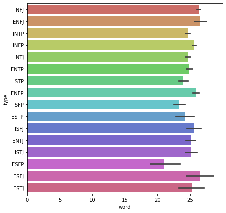

```python
plt.figure(figsize=(7, 7))
sns.barplot(x='word',y='type',data=personality,palette='hls')
```

Bar plot describing compound sentiment count of each of the personality types.

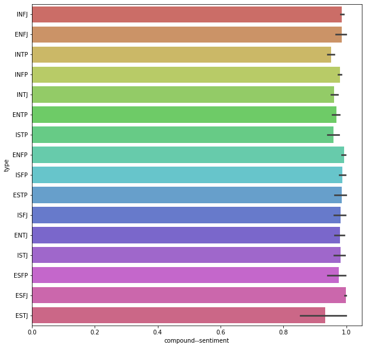

```python
plt.figure(figsize=(10, 10))
sns.barplot(y="type", x="compound--sentiment", data=personality, palette='hls')
```

Bar plot describing positive sentiment count of each of the personality types.

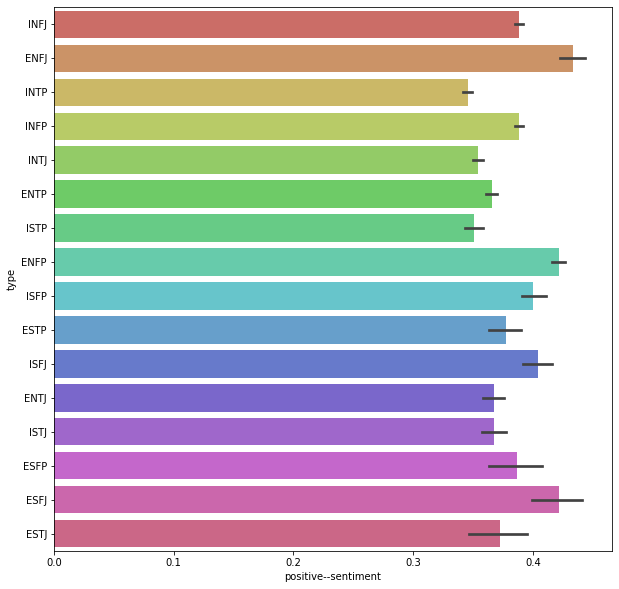

```python
plt.figure(figsize=(10, 10))
sns.barplot(y="type", x="positive--sentiment", data=personality, palette='hls')
```

Bar plot describing negative sentiment count of each of the personality types.

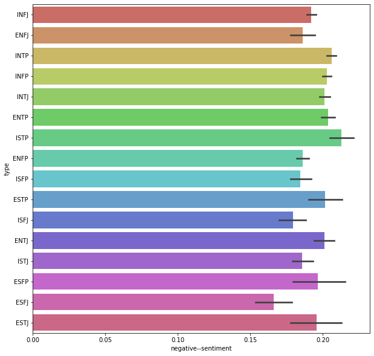

```python
plt.figure(figsize=(10, 10))
sns.barplot(y="type", x="negative--sentiment", data=personality, palette='hls')
```

Bar plot describing neutral sentiment count of each of the personality types.

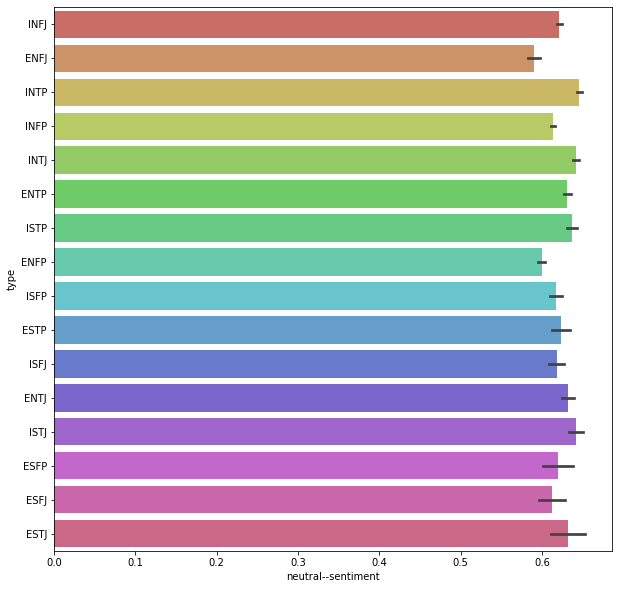

```python
plt.figure(figsize=(10, 10))
sns.barplot(y="type", x="neutral--sentiment", data=personality, palette='hls')
```

Box plot describing question mark count of each of the personality types.

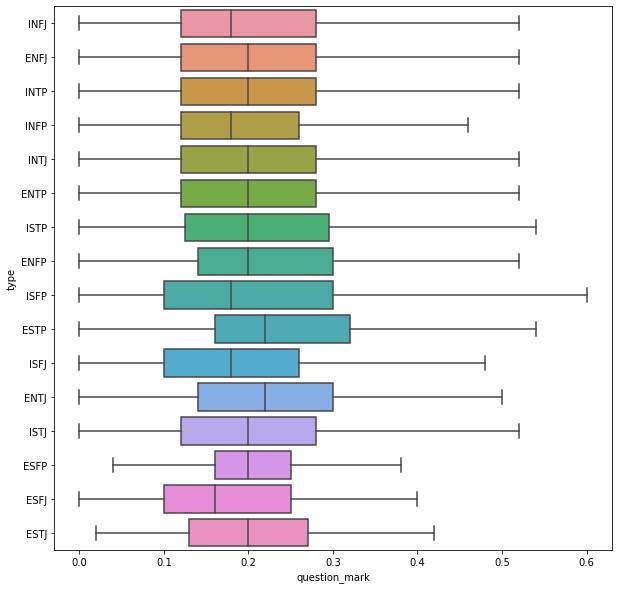

```python
plt.figure(figsize=(10, 10))
sns.boxplot(y="type", x="question_mark", data=personality, showfliers=False)
```

Box plot describing exclamation mark count of each of the personality types.

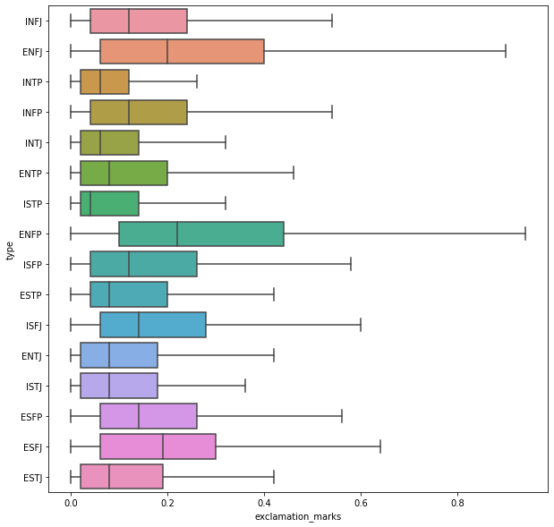

```python
plt.figure(figsize=(10, 10))
sns.boxplot(y="type", x="exclamation_marks", data=personality, showfliers=False)
```

Box plot describing colon count of each of the personality types.

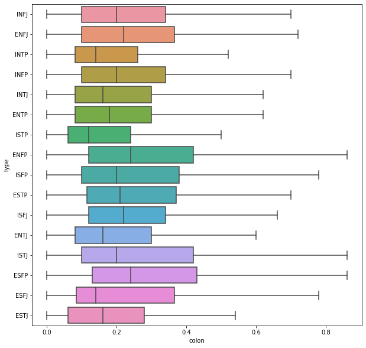

```python
plt.figure(figsize=(10, 10))
sns.boxplot(y="type", x="colon", data=personality, showfliers=False)
```

Box plot describing emoji count of each of the personality types.

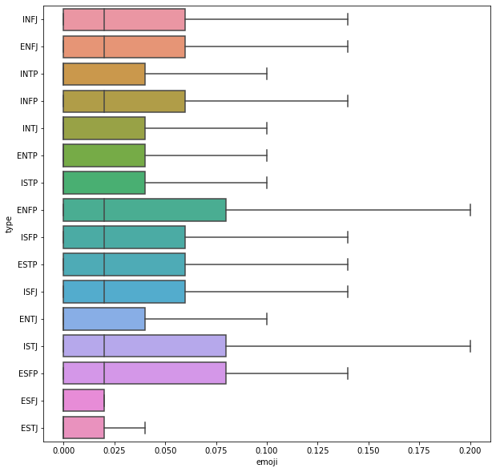

```python
plt.figure(figsize=(10, 10))
sns.boxplot(y="type", x="emoji", data=personality, showfliers=False)
```

Distribution of personality types against number of posts.

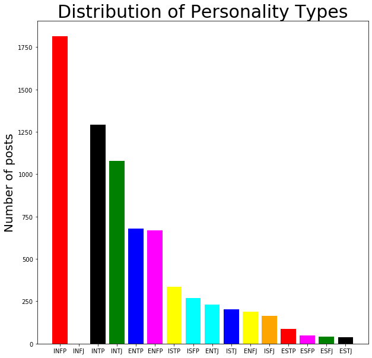

```python
dis = (
    personality.groupby("type")
    .agg({"type": "count"})
    .rename(columns={"type": "count"})
    .sort_values("count", ascending=False)
)
colors = {x: colors[x] for x in dis.index.tolist()}
plt.figure(figsize=(10, 10))
plt.title("Distribution of Personality Types", fontsize=30)
plt.ylabel("Number of posts", fontsize=20)
plt.bar(dis.index, dis["count"], color=list(colors.values()))
plt.show()
```

Now lets find the acccuracy using logistic regression logmodel. ACCURACY

Import the train_test_split module to perform splitting.

```python
from sklearn.model_selection  import train_test_split
```

Define your x and y .

```python
y=personality['Extrovert']
x=personality[['compound--sentiment','positive--sentiment','negative--sentiment','neutral--sentiment']]
```

Perform splitting.

```python
X_train, X_test, y_train, y_test = train_test_split(x,y,test_size=0.30,random_state=42)
```

Logistic model is used to model the probability of a certain event such as pass/fail , alive/dead etc . Import the Logistic Regression module.

```python
from sklearn.linear_model import LogisticRegression
```

Create a Logistic Regression classifier object and fit your model on the training set using fit() and perform prediction on the test set using predict()

```python
logmodel=LogisticRegression()
logmodel.fit(X_train,y_train)
```

```
LogisticRegression(C=1.0, class_weight=None, dual=False, fit_intercept=True,
                   intercept_scaling=1, l1_ratio=None, max_iter=100,
                   multi_class='auto', n_jobs=None, penalty='l2',
                   random_state=None, solver='lbfgs', tol=0.0001, verbose=0,
                   warm_start=False)
```

```python
predictions=logmodel.predict(X_test)
```

Import classification report and confusion matrix and print the same .

```python
from sklearn.metrics import classification_report,confusion_matrix
```

```python
print(confusion_matrix(y_test,predictions))
```

```
[[1986    0]
 [ 591    0]]
```

```python
import warnings
warnings.filterwarnings('ignore')
```

We get precision of 59%.

```python
print(classification_report(y_test,predictions))
```

```
              precision    recall  f1-score   support

           0       0.77      1.00      0.87      1986
           1       0.00      0.00      0.00       591

    accuracy                           0.77      2577
   macro avg       0.39      0.50      0.44      2577
weighted avg       0.59      0.77      0.67      2577
```